# 9.2 - Introducción al análisis de series temporales

26 de marzo de 2020

## Introducción

## Definición de una serie temporal

- Una serie temporal representa una **serie de valores** obtenidos **a lo largo del tiempo** para una variable.
- Suponiendo una serie de \(n\) valores, tomados en diferentes instantes de tiempo \(t=1, t=2,\dots,\) \(t=n\), tendremos:

\[\{x_t: t = 1, 2, \ldots, n\} \: = \: \{x_1, x_2, \ldots, x_n\}\: = \: \{x_t\}\]

- En general, se considera que los valores de la variable se obtienen siempre en instantes de tiempo **equiespaciados** entre sí. En caso contrario, se trataría de una *serie temporal irregular*, que no vamos a tratar aquí.
- Por ejemplo, muchas series temporales surgen al tomar valores de una variable continua (como la temperatura que mide un sensor) cada cierto intervalo de tiempo. A este *intervalo entre muestras* se le llama **periodo de muestreo** (\(\tau\)). Su inversa es la **frecuencia de muestreo** (\(f\)). Para una serie temporal regular:

\[\text{Periodo de muestreo:}\:\:\tau = t_2 - t_1 = t_3 - t_2 = \dots = t_n - t_{n-1}. \\ \text{Frecuencia de muestreo:}\:\:f = \frac{1}{\tau}\]

## ¿Por qué son diferentes?

- La mayoría de las técnicas estadísticas usuales están pensadas para conjuntos de datos formados por observaciones independientes, unas de otras.
- La característica especial de las series temporales es que **sus valores no son independientes entre sí**, en general.
  - Observaciones consecutivas suelen tener relación entre sí.
  - Por tanto tenemos que considerar en el análisis el **orden temporal** de las observaciones.

- Por ejemplo, si hay un sensor que mide mi ubicación y voy a pie, 5 segundos después no podré haber ido muy lejos respecto de mi posición previa.

- Cuando las observaciones sucesivas son dependientes, entonces **los valores futuros se pueden predecir a partir de los valores pasados de la serie**.
- Por este motivo, uno de los principales objetivos del análisis de series temporales es elaborar **modelos de predicción** (en inglés *forecasting*).

## Ejemplo: serie temporal muestreada

- Serie de valores de temperatura en una habitación, tomados cada minuto por un sensor.

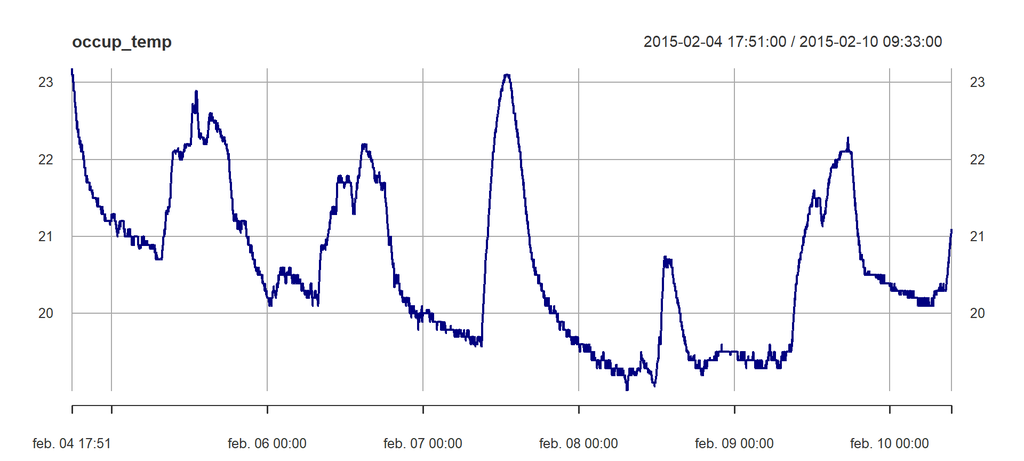

## Ejemplo: serie temporal agregada *ozone*

- Otras series temporales surgen de la **agregación de datos** durante un intervalo. La siguiente gráfica muestra valores promedio mensuales de ozono en una ubicación de EE.UU (1995-2000).

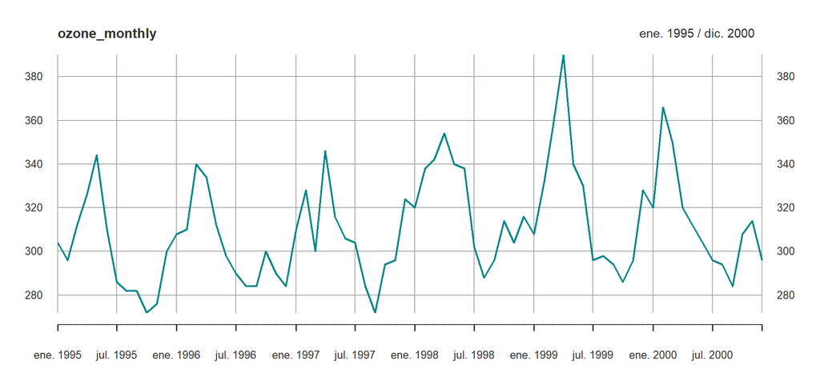

## Ejemplo: serie temporal agregada *sunspots*

- Serie temporal de promedio anual de manchas solares (1749-2008).

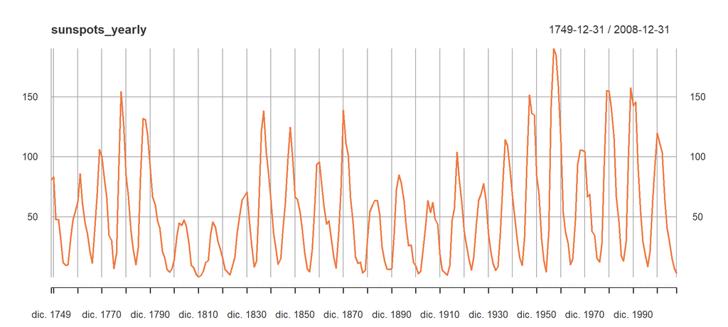

## Representación de series temporales en R

## Series temporales en R

- Existen diferentes clases en R que resuelven varios problemas relacionados con la representación y tratamiento de series temporales.
  - Objetos `ts`, paquetes `its` y `zoo`, `tseries::irts`, `Rmetrics::timeSeries`…
- Esto obliga a constantes cambios de clase (*casting* de variables), en los que se van perdiendo atributos en cada cambio.
- Para resolver estos y otros problemas, proporcionando una interfaz unificada y potente para trabajar con series temporales surgió el paquete `xts`.
- [Ventajas de la clase `xts`](https://cran.r-project.org/web/packages/xts/vignettes/xts.pdf).
  - Paquete basado en la clase `zoo`.
  - Soporta objetos de casi todos los restantes paquetes de series temporales.
  - Formatos de fecha soportados: `POSIXct`, `chron`, `yearmon`, `yearqtr` o `timeDate`.
  - Sintaxis clara y directa para crear nuevas series, indexar, operaciones de agregación, etc.
  - Además de proporcionar soporte para no perder los atributos propios de cada clase original, `xts` permite añadir nuevos atributos a cada serie.

## Lectura de datos `occupancy_data` (UCI)

```r
# https://archive.ics.uci.edu/ml/datasets/Occupancy+Detection+
occup_data <- read_csv("data/occupancy_data/datatraining.txt",
                       col_types = cols(date = col_datetime(format = "%Y-%m-%d %H:%M:%S")))
occup_temp <- xts(occup_data$Temperature, order.by = occup_data$date)
str(occup_temp)
```

```
## An 'xts' object on 2015-02-04 17:51:00/2015-02-10 09:33:00 containing:
##   Data: num [1:8143, 1] 23.2 23.1 23.1 23.1 23.1 ...
##   Indexed by objects of class: [POSIXct,POSIXt] TZ: UTC
##   xts Attributes:
##  NULL
```

## Lectura de datos `ozone` (`nasaweather::atmos`)

```r
# Dataset nasaweather::atmos; see ?atmos
ozone_monthly <- atmos %>%
  select(lat, long, year, month, ozone) %>%
  filter(lat==36.2, long==-113.8)

dates_ozone = as.yearmon(1995 + seq(0, nrow(ozone_monthly)-1)/12)
ozone_monthly <- xts(ozone_monthly$ozone, order.by = dates_ozone)
str(ozone_monthly)
```

```
## An 'xts' object on ene. 1995/dic. 2000 containing:
##   Data: num [1:72, 1] 304 296 312 326 344 310 286 282 282 272 ...
##   Indexed by objects of class: [yearmon] TZ: UTC
##   xts Attributes:
##  NULL
```

## Lectura de datos `sunspots` (`tswge::ss08`)

```r
# Dataset tswge::ss08; see ?ss08
# Annual average sunspot numbers for the years 1749-2008
data(ss08)
sunspots_dates = seq(as.Date("1749-12-31"), length = length(ss08), by = "years")
sunspots_yearly = xts(ss08, order.by = sunspots_dates)
str(sunspots_yearly)
```

```
## An 'xts' object on 1749-12-31/2008-12-31 containing:
##   Data: num [1:260, 1] 80.9 83.4 47.7 47.8 30.7 ...
##   Indexed by objects of class: [Date] TZ: UTC
##   xts Attributes:
##  NULL
```

## Representación gráfica con `xts`

- Uno de los aspectos más potentes de `xts` es que produce por defecto representaciones gráficas de calidad.
- Para generar los gráficos al comienzo de la presentación:

```r
plot(occup_temp)
plot(ozone_monthly)
plot(sunspots_yearly)
```

- Estas llamadas son equivalentes a llamar a la función `plot.xts()` (se autoselecciona) cuando el objeto a representar es de clase `xts`.
- Características a destacar:
  - Etiquetado automático del eje temporal (ahorrando mucho esfuerzo).
  - Información extra en el título del gráfico.
  - Grid de fondo automático, elección de relación de aspecto.